# case study 4 with different data

Lance Dacy, Reanan McDaniel, Shawn Jung, Jonathan Tan

```r
#analysis packages
library(tswge)
library(changepoint)
library(tseries)
library(DataExplorer)
#data manipulation
library(dplyr)
library(lubridate)
library(tibbletime)

#visualization
library(ggplot2)
library(cowplot)
library(kableExtra)

#data source
library(cdcfluview)
```

import data from… ??? https://apps.who.int/flumart/Default?ReportNo=12 query below is SE Asia from 1995 to 2019

```r
raw_data  <- read.csv('D:/SMU/DS 7333 Quantify The World/FluNetInteractiveReport(SE_Asia_1995-2019).csv')
```

Column guide for WHO data csv columns SPEC_RECIEVED_NB - Specimens recieved by the WHO SPEC_PROCESSED_NB - specimens processed by the WHO AH1 - all A type influenza viruses categorized by subtype A(H1N1pdm09 AH3 AH5 ANOTSUBTYPED INF(A) - total of all influenza A viruses detected BYAMAGATA - B(Yamagata lineage) - various types of influenze B type viruses BVICTORIA - B(Victoria Lineage) BNOTDETERMINED INF_B - total influenze B viruses ALL_INF - number of influenze positive viruses ALL_INF2 - number of influenze negative viruses TITLE - ili activity? most have no report as the column

will have to look more into the details, but it looks like this dataset is recording the number of virus strains, not individual cases of that virus. specimens recieved/processed usually matches up with INF + or -, indicating that those specimens were all tested and sorted into either yes, it was an influenza virus, or no, it was not.

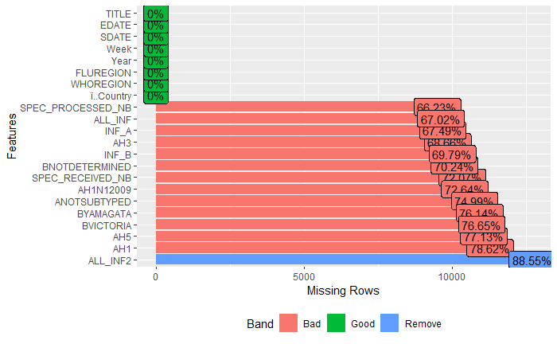

```r
#getting a look at the data
plot_missing(raw_data)
```

This function looks at how many missing rows are present in each column. most of the useful information we want is barely 25% there, indicating that from the date range 1995-2019, barely 5 years of data is usable.

```r
table(raw_data$FLUREGION)
```

```
   Eastern Asia South-East Asia   Southern Asia
           1304            5216            7824
```

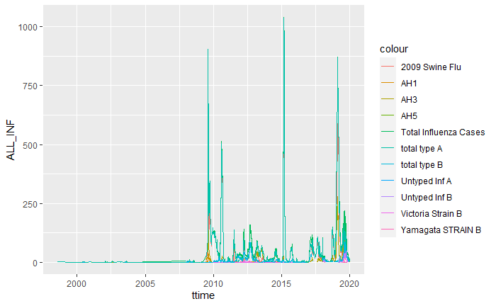

```r
SE_Asia <- raw_data[which(raw_data$FLUREGION == 'Southern Asia'), ] #select rows from SE asia
tlist <- SE_Asia[complete.cases(SE_Asia$ALL_INF), ] #select only rows that aren't missing data in the all_inf column
t_ind <- tlist[which(tlist['ï..Country'] == 'India'), ]
ttime = t_ind$SDATE %>% as.Date("%m/%d/%Y") #store the timeline as date object vector
#it looks like all the weeks fall on the same SDATE's, so it should be safe to use the same date vector for different countries.

ggplot(t_ind) +
  geom_line(aes(x = ttime, y = ALL_INF, col = 'Total Influenza Cases'))+
  geom_line(aes(x = ttime, y = AH1, col = 'AH1'))+
  geom_line(aes(x = ttime, y = AH1N12009, col = '2009 Swine Flu'))+
  geom_line(aes(x = ttime, y = AH3, col = 'AH3'))+
  geom_line(aes(x = ttime, y = AH5, col = 'AH5'))+
  geom_line(aes(x = ttime, y = ANOTSUBTYPED, col = 'Untyped Inf A'))+
  geom_line(aes(x = ttime, y = INF_A, col = 'total type A'))+
  geom_line(aes(x = ttime, y = BYAMAGATA, col = 'Yamagata STRAIN B'))+
  geom_line(aes(x = ttime, y = BVICTORIA, col = 'Victoria Strain B'))+
  geom_line(aes(x = ttime, y = BNOTDETERMINED, col = 'Untyped Inf B'))+
  geom_line(aes(x = ttime, y = INF_B, col = 'total type B'))
```

```r
NA
```

let’s set primary time series to total influenza cases from india *here you should be able to feed in any time series object as ‘tdata’ and have the blocks below work* as long as you have the date values saved to a vector ‘ttime’ as well, but that’s just for the graphing bit

```r
tdata <- t_ind$ALL_INF %>% as.ts()
```

and now we can run hopefully adaptable analysis cells below

actual time series analysis goes here, assuming you have a ts item labeled ‘tdata’

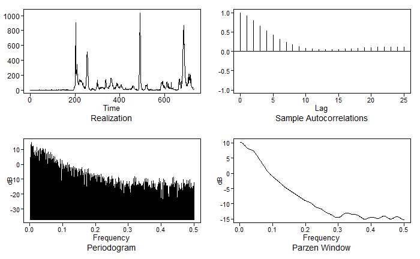

```r
#diagnoses
#wrap objects in invisible() to hide the long console output and leave only the graph
invisible(plotts.sample.wge(tdata))
```

```r
#stationairity
adf.test(tdata)
```

```
p-value smaller than printed p-value
```

```
    Augmented Dickey-Fuller Test

data:  tdata
Dickey-Fuller = -6.6692, Lag order = 8, p-value = 0.01
alternative hypothesis: stationary
```

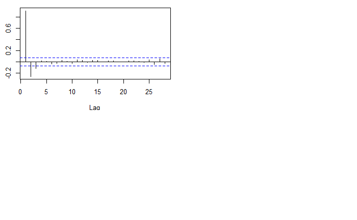

```r
pacf(tdata)

#changepoint
par(mfrow = c(2,1))
```

```r
v2 <- tdata

v2.pelt <- cpt.meanvar(v2, test.stat = 'Poisson', method = "PELT")
plot(v2.pelt, main = 'PELT changes in variance')
cpts.ts(v2.pelt)
```

```
 [1]  36 125 169 194 198 200 202 204 207 209 212 217 231 237 247 250 252 255 257 259 261 266 272 284 293 296 303 334 339 350
[31] 357 365 370 382 391 401 411 414 423 453 464 474 483 485 487 489 491 493 495 497 513 522 524 541 581 584 593 596 607 612
[61] 618 627 629 636 644 660 662 666 670 675 678 681 683 685 687 689 691 693 703 706 714 717 725
```

```r
v2.bs <- cpt.meanvar(v2, test.stat = 'Poisson', method = 'BinSeg')
```

```
The number of changepoints identified is Q, it is advised to increase Q to make sure changepoints have not been missed.
```

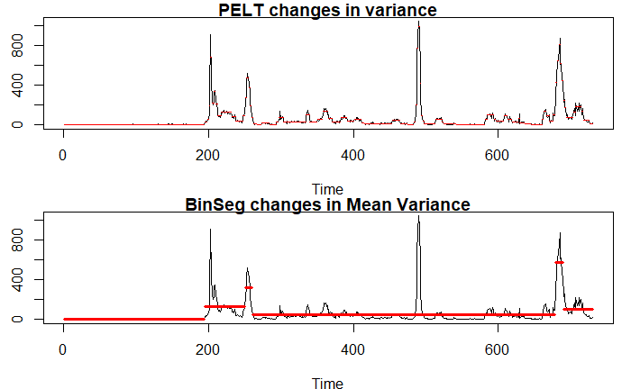

```r
plot(v2.bs, cpt.width = 3, main = 'BinSeg changes in Mean Variance')
```

```r
cpts.ts(v2.bs)
```

```
[1] 194 250 260 678 689
```

```r
#model fitting
pspan = 0:5 #range of values to look for possible p and q coefficients for AR and MA
qspan = 0:5
aic_results <- aic5.wge(tdata, p = pspan, q = qspan)
```

```
---------WORKING... PLEASE WAIT...
```

```
possible convergence problem: optim gave code = 1possible convergence problem: optim gave code = 1
```

```
Five Smallest Values of  aic
```

```r
bic_results <- aic5.wge(tdata, p = pspan, q = qspan, type = 'bic')
```

```
---------WORKING... PLEASE WAIT...
```

```
possible convergence problem: optim gave code = 1possible convergence problem: optim gave code = 1
```

```
Five Smallest Values of  bic
```

```r
aic_results
```

|  | p | q | aic |
| --- | --- | --- | --- |
| 19 | 3 | 0 | 7.672361 |
| 15 | 2 | 2 | 7.674742 |
| 25 | 4 | 0 | 7.674830 |
| 20 | 3 | 1 | 7.674869 |
| 10 | 1 | 3 | 7.674893 |

```r
bic_results
```

|  | p | q | bic |
| --- | --- | --- | --- |
| 19 | 3 | 0 | 7.697528 |
| 14 | 2 | 1 | 7.700397 |
| 9 | 1 | 2 | 7.700794 |
| 13 | 2 | 0 | 7.703033 |
| 15 | 2 | 2 | 7.706201 |

```r
m1 = est.arma.wge(tdata, p = aic_results[1, 1], q = aic_results[1, 2], factor = TRUE) #feed top AIC or BIC into arma estimation to generate coefficients
```

```
Coefficients of Original polynomial:
1.1177 -0.1225 -0.1197

Factor                 Roots                Abs Recip    System Freq
1-1.3717B+0.4710B^2    1.4561+-0.0530i      0.6863       0.0058
1+0.2541B             -3.9361               0.2541       0.5000
```

```r
m1$phi
```

```
[1]  1.1176752 -0.1225349 -0.1196717
```

```r
m1$theta
```

```
[1] 0
```

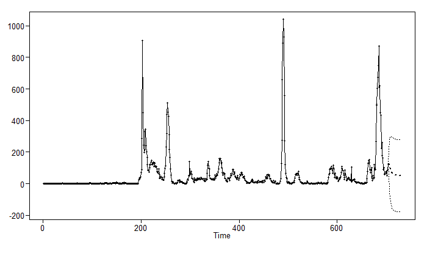

```r
#simple single forecast and test
weeks_compare = 26 #how many weeks to reserve for testing
f1 <- tdata[1:(length(tdata)-weeks_compare)] %>% fore.aruma.wge(phi = m1$phi, theta = m1$theta, d = 0, n.ahead = weeks_compare)
```

```r
mse <- (tdata[((length(tdata)-weeks_compare)+1):(length(tdata))] - f1$f)^2 %>% mean()
paste('Mean Squared Error: ', mse)
```

```
[1] "Mean Squared Error:  4422.05720416835"
```

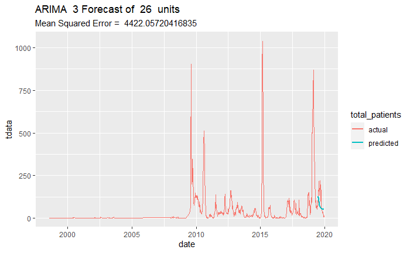

```r
#change x and y line names to match whatever dataframe you've stored the time series in
timeFrame <- data.frame(date = ttime, inf_cases = tdata)
g3 <- ggplot(timeFrame)+
  geom_line(aes(x = date, y = tdata, color = 'black'), size = 0.5)+
  geom_line(aes(x = date, y = c(rep(NA, length(tdata)-weeks_compare), f1$f), color = 'red'), size= 1) +
  scale_color_discrete(name = "total_patients", labels = c('actual', 'predicted')) +
  ggtitle(paste('ARIMA ', aic_results[1, ],  'Forecast of ', weeks_compare, ' units'), subtitle = paste('Mean Squared Error = ', mse))

g3
```